# Homeowrk #5

Jaxon Stuhr

2022-11-14

## Elastic Net Tuning

Data Source: https://www.kaggle.com/abcsds/pokemon.

The [Pokémon](https://www.pokemon.com/us/) franchise encompasses video games, TV shows, movies, books, and a card game. This data set was drawn from the video game series and contains statistics about 721 Pokémon, or “pocket monsters.” In Pokémon games, the user plays as a trainer who collects, trades, and battles Pokémon to (a) collect all the Pokémon and (b) become the champion Pokémon trainer.

Each Pokémon has a [primary type](https://bulbapedia.bulbagarden.net/wiki/Type) (some even have secondary types). Based on their type, a Pokémon is strong against some types, and vulnerable to others. (Think rock, paper, scissors.) A Fire-type Pokémon, for example, is vulnerable to Water-type Pokémon, but strong against Grass-type.

[figure not shown]

Fig 1. Vulpix, a Fire-type fox Pokémon from Generation 1.

The goal of this assignment is to build a statistical learning model that can predict the **primary type** of a Pokémon based on its generation, legendary status, and six battle statistics.

Read in the file and familiarize yourself with the variables using `pokemon_codebook.txt`.

```r
# read in pokemon data, set seed
pokemon_raw = read_csv(here("data", "Pokemon.csv"))
set.seed(1739)
```

### Exercise 1

```r
# clean names of pokemon data
pokemon_clean = pokemon_raw %>%
  clean_names()
```

**clean_names()** removed all capitals, spaces and characters other than letters, numbers, and “_” from the column names of pokemon_raw. These leaves a dataset with standardized parameter names that is much easier to work with.

### Exercise 2

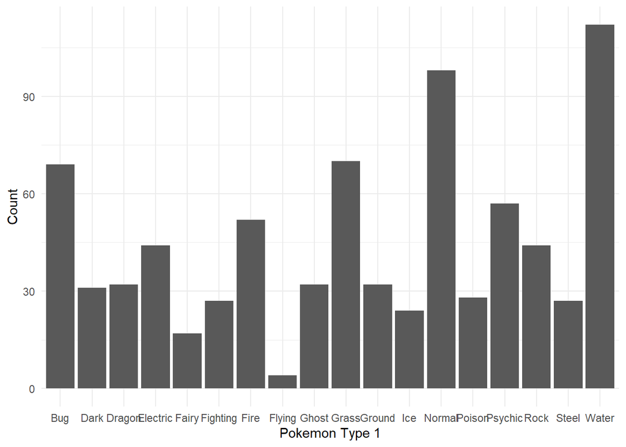

```r
# bar plot of type_1
ggplot(pokemon_clean, aes(x = type_1)) +
  geom_bar() +
  labs(x = "Pokemon Type 1", y = "Count") +
  theme_minimal()
```

There are 18 classes of pokemon in the **type_1** parameter, with all types having at least 15 observations other than “Flying”.

```r
# filter for only classes in: Bug, Fire, Grass, Normal, Water, or Psychic
pokemon = pokemon_clean %>%
  filter(type_1 %in% c("Bug", "Fire", "Grass", "Normal", "Water", "Psychic")) %>%
# convert type_1 and legendary to factors
  mutate(type_1 = factor(type_1)) %>%
  mutate(legendary = factor(legendary, levels = c("TRUE", "FALSE"))) %>%
  mutate(generation = factor(generation))
```

### Exercise 3

```r
# split pokemon data stratified by type_1
pokemon_split <- initial_split(pokemon, prop = 0.75,
                                strata = "type_1")
pokemon_train <- training(pokemon_split)
pokemon_test <- testing(pokemon_split)
# verify number of observations
dim(pokemon_train)
```

```
## [1] 341  13
```

```r
dim(pokemon_test)
```

```
## [1] 117  13
```

```r
# v-fold cross validation w v = 5
pokemon_folds <- vfold_cv(pokemon_train, v = 5, strata = "type_1")
```

We straify the folds because there are a limited number of observations of each class and we want to make sure that none of the folds exclude a certain class of type_1.

### Exercise 4

```r
# generate recipe to predict type_1
pokemon_recipe <- recipe(type_1 ~ legendary + generation + sp_atk + attack + speed + defense + hp + sp_def, data = pokemon_train) %>%
  # dummy vars for nominal predictors
  step_dummy(legendary, generation) %>%
  # center
  step_center(all_predictors()) %>%
  # scale
  step_scale(all_predictors())
```

### Exercise 5

```r
# build model using multinom regression from glmnet engine, tuning penalty and mixture
pokemon_model <-
  multinom_reg(penalty = tune(), mixture = tune()) %>%
  set_mode("classification") %>%
  set_engine("glmnet")
# set up workflow
pokemon_workflow <- workflow() %>%
  add_model(pokemon_model) %>%
  add_recipe(pokemon_recipe)
```

We will be fitting 10 (penalty) x 10 (mixture) x 5 (folds) = 500 models

```r
# set up regular grid with mixture ranging from (0,1), penalty from (-5,5), and 10 levels of each
#pokemon_grid <- grid_regular(penalty(range = c(-5, 5)),  levels = 10)
pokemon_grid <- grid_regular(penalty(range = c(-5, 5)), mixture(range = c(0, 1)), levels = c(penalty = 10, mixture = 10))
```

### Exercise 6

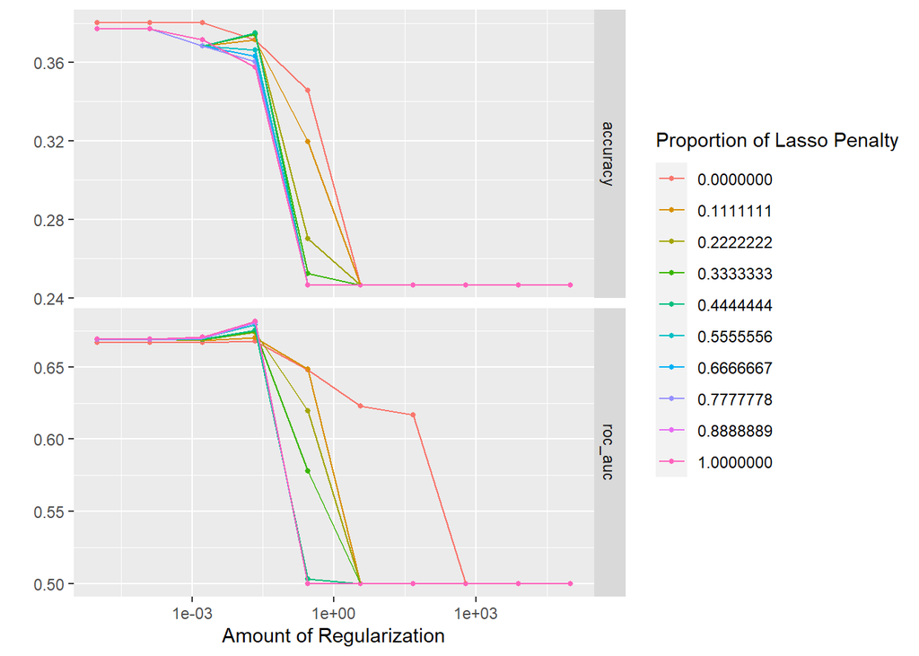

```r
# fitting all 100 models with tune_grid()
pokemon_tuned_models <- tune_grid(
  pokemon_workflow,
  resamples = pokemon_folds,
  grid = pokemon_grid
)
# autoplot to view results
autoplot(pokemon_tuned_models)
```

### Exercise 7

```r
# find best model according to roc_auc()
best_model <- select_best(pokemon_tuned_models, metric = "roc_auc")
# finalize workflow for this model
pokemon_final_wflow <- finalize_workflow(pokemon_workflow, best_model)
# fit final model to entire training set
pokemon_final_fit <- fit(pokemon_final_wflow, data = pokemon_train)
# evaluate performance on testing data

augment(pokemon_final_fit, new_data = pokemon_test) %>%
  accuracy(truth = type_1, estimate = .pred_class)
```

```
## # A tibble: 1 × 3
##   .metric  .estimator .estimate
##   <chr>    <chr>          <dbl>
## 1 accuracy multiclass     0.342
```

The best model only had a 34% accuracy when predicting the class of the testing data.

### Exercise 8

```r
# create class probabilities data frame
class_probs = augment(pokemon_final_fit, new_data = pokemon_test)
# calculate ROC_AUC
roc_auc = class_probs %>%
  roc_auc(truth = type_1, .pred_Bug:.pred_Water)

roc_auc
```

```
## # A tibble: 1 × 3
##   .metric .estimator .estimate
##   <chr>   <chr>          <dbl>
## 1 roc_auc hand_till      0.708
```

The overall ROC AUC on the pokemon testing set is .71

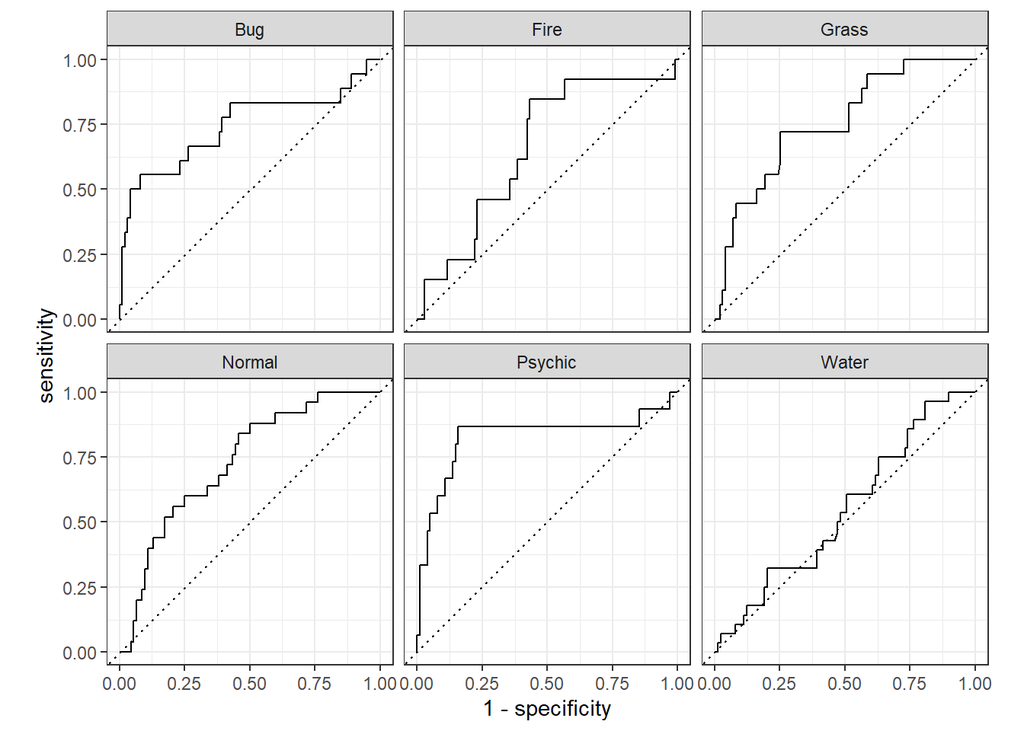

```r
# plot ROC curves for all types
roc_curve(class_probs, .pred_Bug:.pred_Water, truth = type_1) %>%
  autoplot()
```

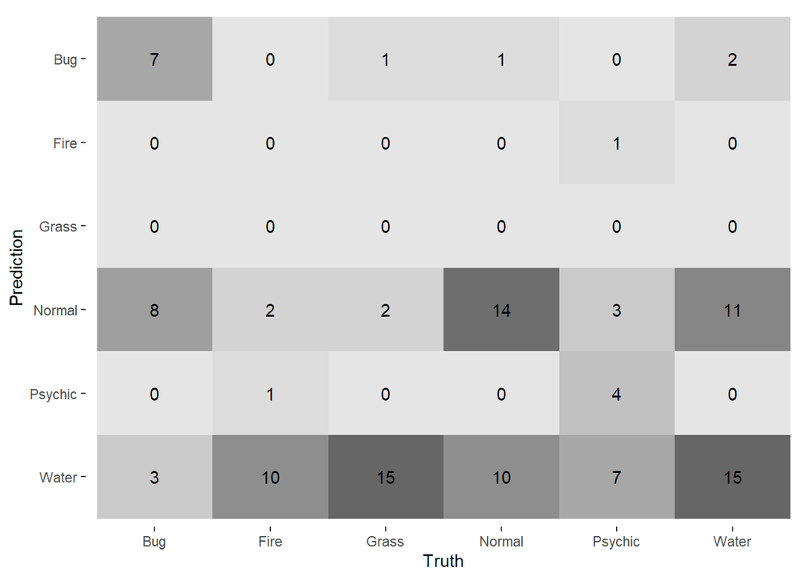

```r
# build confusion matrix
cm = conf_mat(class_probs, estimate = .pred_class, truth = type_1)
# plot heatmap
autoplot(cm, type = "heatmap")
```

## For 231 Students

### Exercise 9

In the 2020-2021 season, Stephen Curry, an NBA basketball player, made 337 out of 801 three point shot attempts (42.1%). Use bootstrap resampling on a sequence of 337 1’s (makes) and 464 0’s (misses). For each bootstrap sample, compute and save the sample mean (e.g. bootstrap FG% for the player). Use 1000 bootstrap samples to plot a histogram of those values. Compute the 99% bootstrap confidence interval for Stephen Curry’s “true” end-of-season FG% using the quantile function in R. Print the endpoints of this interval.

```r
# build sequence of Steph Curries makes and misses
makes = matrix(data = 1, nrow = 337, ncol = 1)
misses = matrix(data = 0, nrow = 464, ncol = 1)
shots = rbind(makes, misses)
```

```r
# take 1000 samples and calculate means from sequence
means = matrix(data = 0, nrow = 1000, ncol = 1)
for (i in 1:1000) {
  means[i] = mean(sample(shots, replace = TRUE))
}
means = data.frame(means)
```

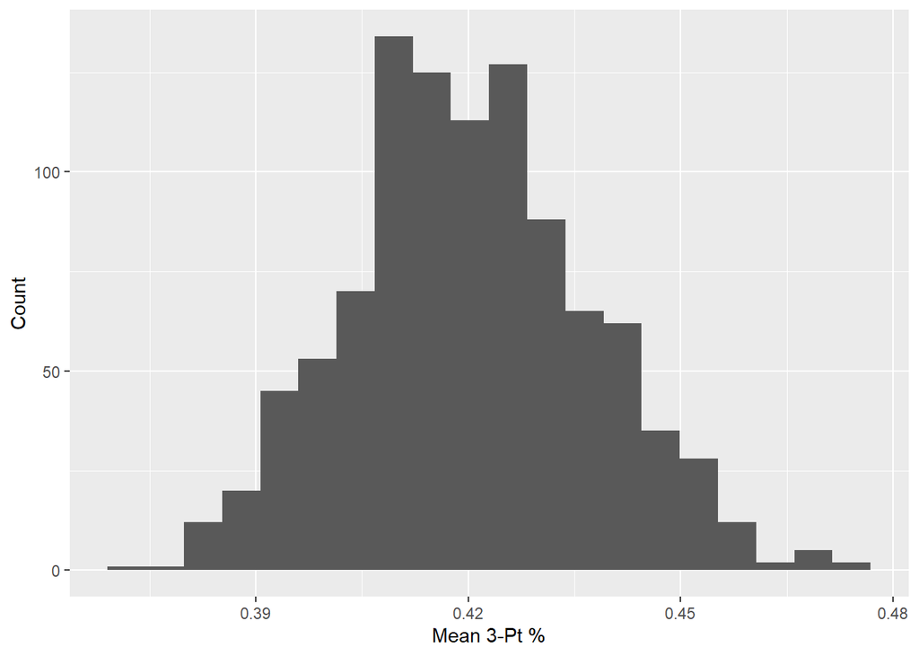

```r
# plot distribution of mean 3 pt %
ggplot(means, aes(x = means)) +
  geom_histogram(bins = 20) +
  labs(x = "Mean 3-Pt %", y = "Count")
```

```r
# calculate 99% confidence interval
quantile(means$means, probs = c(.005, .995) )
```

```
##      0.5%     99.5%
## 0.3820162 0.4681648
```